Artificial Intelligence and Machine Learning

Ensemble Techniques and Model Tuning

# **Problem Statement**

## Context

Business communities in the United States are facing high demand for human resources, but one of the constant challenges is identifying and attracting the right talent, which is perhaps the most important element in remaining competitive. Companies in the United States look for hard-working, talented, and qualified individuals both locally as well as abroad.

The Immigration and Nationality Act (INA) of the US permits foreign workers to come to the United States to work on either a temporary or permanent basis. The act also protects US workers against adverse impacts on their wages or working conditions by ensuring US employers' compliance with statutory requirements when they hire foreign workers to fill workforce shortages. The immigration programs are administered by the Office of Foreign Labor Certification (OFLC).

OFLC processes job certification applications for employers seeking to bring foreign workers into the United States and grants certifications in those cases where employers can demonstrate that there are not sufficient US workers available to perform the work at wages that meet or exceed the wage paid for the occupation in the area of intended employment.

## Objective

In FY 2016, the OFLC processed 775,979 employer applications for 1,699,957 positions for temporary and permanent labor certifications. This was a nine percent increase in the overall number of processed applications from the previous year. The process of reviewing every case is becoming a tedious task as the number of applicants is increasing every year.

The increasing number of applicants every year calls for a Machine Learning based solution that can help in shortlisting the candidates having higher chances of VISA approval. OFLC has hired the firm EasyVisa for data-driven solutions. You as a data scientist at EasyVisa have to analyze the data provided and, with the help of a classification model:

- Facilitate the process of visa approvals.
- Recommend a suitable profile for the applicants for whom the visa should be certified or denied based on the drivers that significantly influence the case status.

## Data Description

The data contains the different attributes of employee and the employer. The detailed data dictionary is given below.

- case_id: ID of each visa application
- continent: Information of continent the employee
- education_of_employee: Information of education of the employee
- has_job_experience: Does the employee has any job experience? Y= Yes; N = No
- requires_job_training: Does the employee require any job training? Y = Yes; N = No
- no_of_employees: Number of employees in the employer's company
- yr_of_estab: Year in which the employer's company was established
- region_of_employment: Information of foreign worker's intended region of employment in the US.
- prevailing_wage: Average wage paid to similarly employed workers in a specific occupation in the area of intended employment. The purpose of the prevailing wage is to ensure that the foreign worker is not underpaid compared to other workers offering the same or similar service in the same area of employment.
- unit_of_wage: Unit of prevailing wage. Values include Hourly, Weekly, Monthly, and Yearly.
- full_time_position: Is the position of work full-time? Y = Full Time Position; N = Part Time Position
- case_status: Flag indicating if the Visa was certified or denied

## Note: This is a sample solution for the project. Projects will NOT be graded on the basis of how well the submission matches this sample solution. Projects will be graded on the basis of the rubric only.

# **Importing necessary libraries**

```python
# Installing the libraries with the specified version.
# !pip install numpy==2.0.2 pandas==2.2.2 scikit-learn==1.6.1 matplotlib==3.10.0 seaborn==0.13.2 xgboost==3.0.5 -q --user
```

**Note**: *After running the above cell, kindly restart the notebook kernel and run all cells sequentially from the start again.*

```python
# Libraries to help with reading and manipulating data
import numpy as np
import pandas as pd

# Library to split data
from sklearn.model_selection import train_test_split

# libaries to help with data visualization
import matplotlib.pyplot as plt
import seaborn as sns

# Removes the limit for the number of displayed columns
pd.set_option("display.max_columns", None)
# Sets the limit for the number of displayed rows
pd.set_option("display.max_rows", 100)

# To oversample and undersample data
from imblearn.over_sampling import SMOTE
from imblearn.under_sampling import RandomUnderSampler

# Libraries different ensemble classifiers
from sklearn.ensemble import (
    BaggingClassifier,
    RandomForestClassifier,
    AdaBoostClassifier,
    GradientBoostingClassifier,
    StackingClassifier,
)

from xgboost import XGBClassifier
from sklearn.tree import DecisionTreeClassifier

# Libraries to get different metric scores
from sklearn import metrics
from sklearn.metrics import (
    confusion_matrix,
    accuracy_score,
    precision_score,
    recall_score,
    f1_score,
)

# To tune different models
from sklearn.model_selection import GridSearchCV

import warnings
warnings.filterwarnings("ignore")

from VKPyKit.EDA import *
from VKPyKit.DT import *
from VKPyKit.MLM import *
```

# **Loading the dataset**

```python
visa = pd.read_csv("EasyVisa.csv")
df = visa.copy()
```

# **Overview of the Dataset**

```python
display(HTML("<h2>Info</h2>", df.info()))
```

```
<class 'pandas.core.frame.DataFrame'>
RangeIndex: 25480 entries, 0 to 25479
Data columns (total 12 columns):
 #   Column                 Non-Null Count  Dtype
---  ------                 --------------  -----
 0   case_id                25480 non-null  object
 1   continent              25480 non-null  object
 2   education_of_employee  25480 non-null  object
 3   has_job_experience     25480 non-null  object
 4   requires_job_training  25480 non-null  object
 5   no_of_employees        25480 non-null  int64
 6   yr_of_estab            25480 non-null  int64
 7   region_of_employment   25480 non-null  object
 8   prevailing_wage        25480 non-null  float64
 9   unit_of_wage           25480 non-null  object
 10  full_time_position     25480 non-null  object
 11  case_status            25480 non-null  object
dtypes: float64(1), int64(2), object(9)
memory usage: 2.3+ MB
```

Info

**Observation**

1. 9 Columns are objects and 3 numeric

```python
display(HTML("<h2>Columns</h2>"),df.columns)
```

Columns

```
Index(['case_id', 'continent', 'education_of_employee', 'has_job_experience',
       'requires_job_training', 'no_of_employees', 'yr_of_estab',
       'region_of_employment', 'prevailing_wage', 'unit_of_wage',
       'full_time_position', 'case_status'],
      dtype='object')
```

```python
display(HTML("<h2>Head</h2>"),df.head())
display(HTML("<h2>Tail</h2>"),df.tail())
display(HTML("<h2>Shape</h2>"),df.shape)
```

Head

|  | case_id | continent | education_of_employee | has_job_experience | requires_job_training | no_of_employees | yr_of_estab | region_of_employment | prevailing_wage | unit_of_wage | full_time_position | case_status |
| --- | --- | --- | --- | --- | --- | --- | --- | --- | --- | --- | --- | --- |
| 0 | EZYV01 | Asia | High School | N | N | 14513 | 2007 | West | 592.2029 | Hour | Y | Denied |
| 1 | EZYV02 | Asia | Master's | Y | N | 2412 | 2002 | Northeast | 83425.6500 | Year | Y | Certified |
| 2 | EZYV03 | Asia | Bachelor's | N | Y | 44444 | 2008 | West | 122996.8600 | Year | Y | Denied |
| 3 | EZYV04 | Asia | Bachelor's | N | N | 98 | 1897 | West | 83434.0300 | Year | Y | Denied |
| 4 | EZYV05 | Africa | Master's | Y | N | 1082 | 2005 | South | 149907.3900 | Year | Y | Certified |

Tail

|  | case_id | continent | education_of_employee | has_job_experience | requires_job_training | no_of_employees | yr_of_estab | region_of_employment | prevailing_wage | unit_of_wage | full_time_position | case_status |
| --- | --- | --- | --- | --- | --- | --- | --- | --- | --- | --- | --- | --- |
| 25475 | EZYV25476 | Asia | Bachelor's | Y | Y | 2601 | 2008 | South | 77092.57 | Year | Y | Certified |
| 25476 | EZYV25477 | Asia | High School | Y | N | 3274 | 2006 | Northeast | 279174.79 | Year | Y | Certified |
| 25477 | EZYV25478 | Asia | Master's | Y | N | 1121 | 1910 | South | 146298.85 | Year | N | Certified |
| 25478 | EZYV25479 | Asia | Master's | Y | Y | 1918 | 1887 | West | 86154.77 | Year | Y | Certified |
| 25479 | EZYV25480 | Asia | Bachelor's | Y | N | 3195 | 1960 | Midwest | 70876.91 | Year | Y | Certified |

Shape

```
(25480, 12)
```

**Observation**

1. 25480 records in data
2. Unit of wage varies, may need to noramlized.
3. Case_id is just an identifier, and may need to be dropped.

# Exploratory Data Analysis (EDA)

## Checks

```python
## Null values
display(HTML("<h2>Is null values:</h2>"),df.isnull().sum())
```

Is null values:

```
case_id                  0
continent                0
education_of_employee    0
has_job_experience       0
requires_job_training    0
no_of_employees          0
yr_of_estab              0
region_of_employment     0
prevailing_wage          0
unit_of_wage             0
full_time_position       0
case_status              0
dtype: int64
```

**Observation**

1. There are no null values in any column

```python
display(HTML("<h2>Is duplicated values:</h2>"),df.duplicated().sum())
```

Is duplicated values:

```
0
```

**Observation**

1. No duplicate values.

```python
display(HTML("<h2>Describe:</h2>"),df.describe().T)
display(HTML("<h2>Describe / include O:</h2>"),df.describe(include="O").T)
```

Describe:

|  | count | mean | std | min | 25% | 50% | 75% | max |
| --- | --- | --- | --- | --- | --- | --- | --- | --- |
| no_of_employees | 25480.0 | 5667.043210 | 22877.928848 | -26.0000 | 1022.00 | 2109.00 | 3504.0000 | 602069.00 |
| yr_of_estab | 25480.0 | 1979.409929 | 42.366929 | 1800.0000 | 1976.00 | 1997.00 | 2005.0000 | 2016.00 |
| prevailing_wage | 25480.0 | 74455.814592 | 52815.942327 | 2.1367 | 34015.48 | 70308.21 | 107735.5125 | 319210.27 |

Describe / include O:

|  | count | unique | top | freq |
| --- | --- | --- | --- | --- |
| case_id | 25480 | 25480 | EZYV01 | 1 |
| continent | 25480 | 6 | Asia | 16861 |
| education_of_employee | 25480 | 4 | Bachelor's | 10234 |
| has_job_experience | 25480 | 2 | Y | 14802 |
| requires_job_training | 25480 | 2 | N | 22525 |
| region_of_employment | 25480 | 5 | Northeast | 7195 |
| unit_of_wage | 25480 | 4 | Year | 22962 |
| full_time_position | 25480 | 2 | Y | 22773 |
| case_status | 25480 | 2 | Certified | 17018 |

**Observations**

1. Negatives in number of employees, need fixing
2. Year of establishment may need to change to years in operation as just a number, not year. Ex. 2000 would become 25.

```python
display(HTML("<h2>Case status count:</h2>"), df["case_status"].value_counts(normalize=True)*100, df["case_status"].value_counts())
```

Case status count:

```
case_status
Certified    66.789639
Denied       33.210361
Name: proportion, dtype: float64
```

```
case_status
Certified    17018
Denied        8462
Name: count, dtype: int64
```

**Observation**

1. Approx spread between Case status is 66-33 percent.
2. More certified cases than denied.

```python
# let's check for missing values in the data
round(df.isnull().sum() / df.isnull().count() * 100, 2)
```

```
case_id                  0.0
continent                0.0
education_of_employee    0.0
has_job_experience       0.0
requires_job_training    0.0
no_of_employees          0.0
yr_of_estab              0.0
region_of_employment     0.0
prevailing_wage          0.0
unit_of_wage             0.0
full_time_position       0.0
case_status              0.0
dtype: float64
```

**Observation**

1. No missing values.

```python
display(HTML("<h2>No of Employees</h2>"),df.loc[df["no_of_employees"] < 0]['no_of_employees'] , df.loc[df["no_of_employees"] < 0].shape)
```

No of Employees

```
245     -25
378     -11
832     -17
2918    -26
6439    -14
6634    -26
7224    -25
7281    -14
7318    -26
7761    -11
9872    -26
11493   -14
13471   -17
14022   -11
14146   -26
```

[output cut: 19 more lines]

```
(33, 12)
```

**Observation**

1. 33 rows are negetive no of emplyees.

```python
#Let's fix the negetive employee count, only 33 have negative value, so we will convert them to positive
df["no_of_employees"] = abs(df["no_of_employees"])
display(df.loc[df["no_of_employees"] < 0].shape)
```

```
(0, 12)
```

```python
#Let's drop Case Id, it is unique anyways
df.drop(["case_id"], axis=1, inplace=True)
```

## Univariate Analysis

### Lay of the land

```python
# list of all categorical variables
cat_col = df.columns

# printing the number of occurrences of each unique value in each categorical column
for column in cat_col:
    print(df[column].value_counts(normalize=True)*100)
    print("-" * 50)
```

```
continent
Asia             66.173469
Europe           14.646782
North America    12.919937
South America     3.343799
Africa            2.162480
Oceania           0.753532
Name: proportion, dtype: float64
--------------------------------------------------
education_of_employee
Bachelor's     40.164835
Master's       37.810047
High School    13.422292
Doctorate       8.602826
Name: proportion, dtype: float64
--------------------------------------------------
has_job_experience
Y    58.092622
N    41.907378
Name: proportion, dtype: float64
--------------------------------------------------
requires_job_training
N    88.402669
Y    11.597331
Name: proportion, dtype: float64
--------------------------------------------------
no_of_employees
183      0.070644
854      0.062794
724      0.062794
766      0.058870
1476     0.058870
           ...
5876     0.003925
5536     0.003925
47866    0.003925
4700     0.003925
40224    0.003925
Name: proportion, Length: 7105, dtype: float64
--------------------------------------------------
```

[output cut: 38 more lines]

```
Hour      8.465463
Week      1.067504
Month     0.349294
Name: proportion, dtype: float64
--------------------------------------------------
full_time_position
Y    89.375981
N    10.624019
Name: proportion, dtype: float64
--------------------------------------------------
case_status
Certified    66.789639
Denied       33.210361
Name: proportion, dtype: float64
--------------------------------------------------
```

**Observation**

### Observations on education of employee

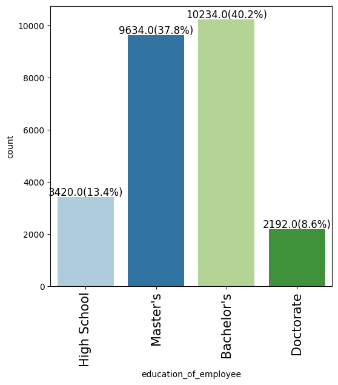

```python
EDA.barplot_labeled(data=df,feature="education_of_employee",percentages=True)
```

#### Note:

1. Masters and Bachelors make 78% of all records followed by highschool and doctorate at lowest 8.6%

### Observations on region of employment

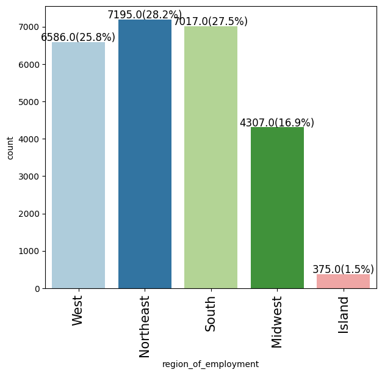

```python
EDA.barplot_labeled(data=df,feature="region_of_employment",percentages=True)
```

#### Note

1. West, Northwest adn South has equally ~ 25% +
2. Island is the lowest

### Observations on job experience

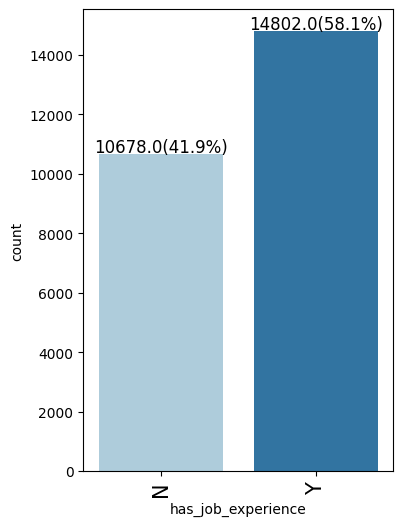

```python
EDA.barplot_labeled(data=df,feature="has_job_experience",percentages=True)
```

#### Note

1. Job experience is 58% - 41% split

### Observations on no_of_employees

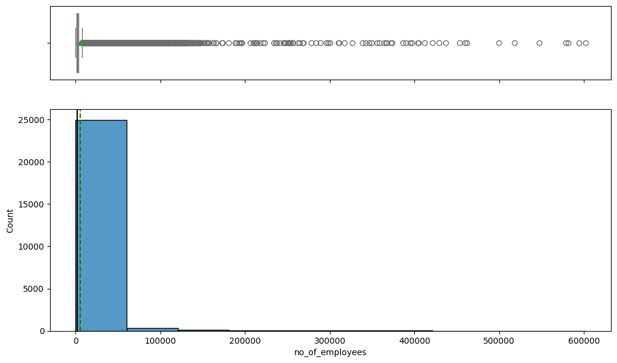

```python
EDA.histogram_boxplot(df,"no_of_employees",bins=10)
```

### Observations on yr_of_estab

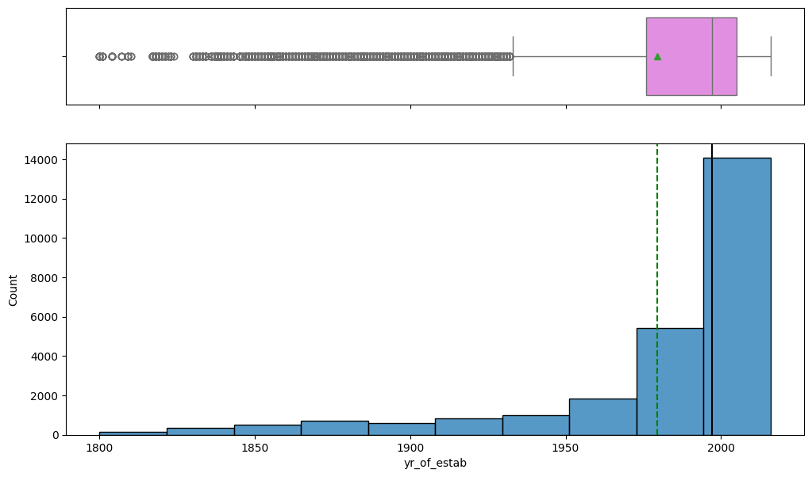

```python
EDA.histogram_boxplot(df,"yr_of_estab",bins=10)
```

### Observations on full_time_position

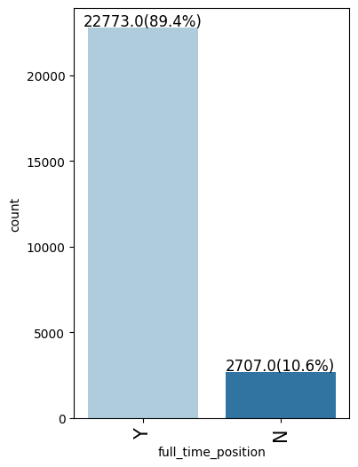

```python
EDA.barplot_labeled(data=df,feature="full_time_position",percentages=True)
```

#### Note

1. Full time position has 89-10% split

### Observations on Continent

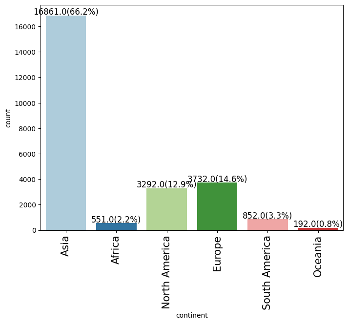

```python
EDA.barplot_labeled(data=df,feature="continent",percentages=True)
```

#### Note

1. Asia takes the most 66% and then followed by NA and Europe, and third group can be Adrica, SA, and Oceania.

### Observations on Training

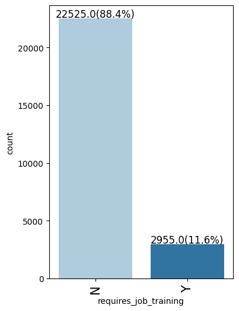

```python
EDA.barplot_labeled(data=df,feature="requires_job_training",percentages=True)
```

### Observations on prevailing_wage

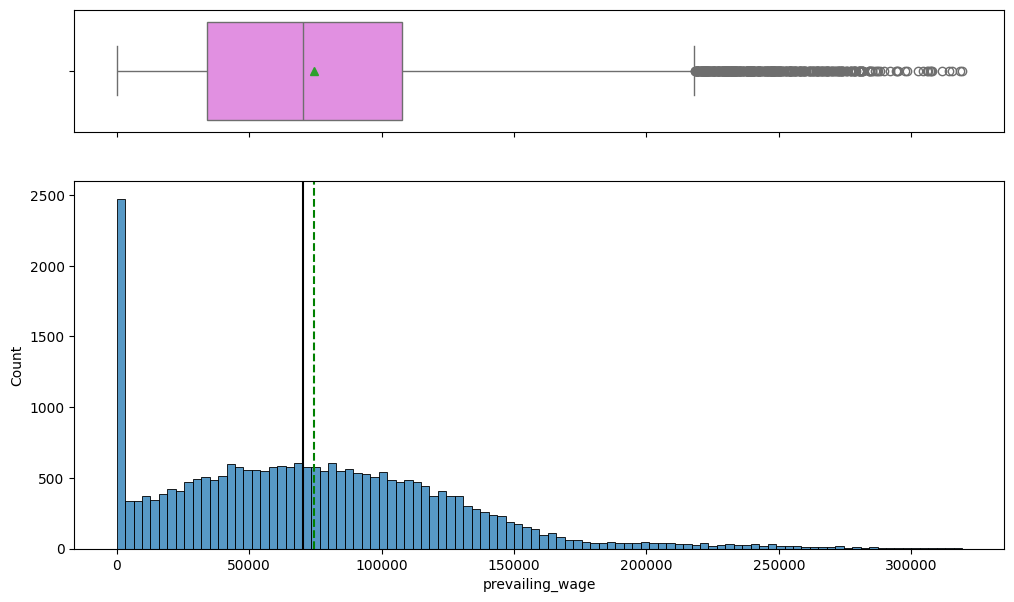

```python
EDA.histogram_boxplot(data=df,feature="prevailing_wage",bins=100)
```

### Observations on unit_of_wage

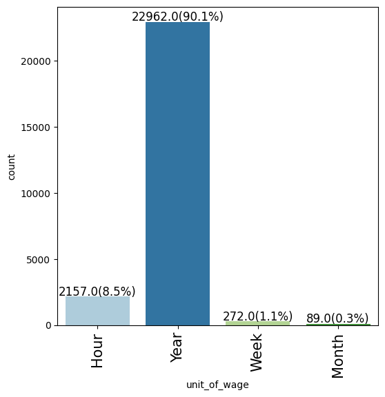

```python
EDA.barplot_labeled(data=df,feature="unit_of_wage",percentages=True)
```

### Observations on case status

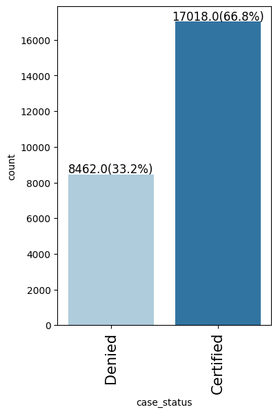

```python
EDA.barplot_labeled(data=df,feature="case_status",percentages=True)
```

- 66.8% of the visas were certified.

## Bivariate Analysis

### **Pivot the columns first against case status.**

Pivot table for all numerical features

Pivot table for case_status for no_of_employees

| case_status | min no_of_employees | max no_of_employees | mean no_of_employees | median no_of_employees | std no_of_employees | count no_of_employees |
| --- | --- | --- | --- | --- | --- | --- |
| Certified | 11 | 602069 | 5807.055882 | 2147.0 | 23119.565783 | 17018 |
| Denied | 11 | 594472 | 5385.601040 | 2032.5 | 22382.740832 | 8462 |

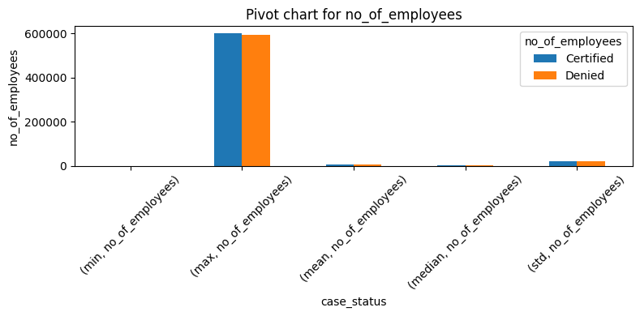

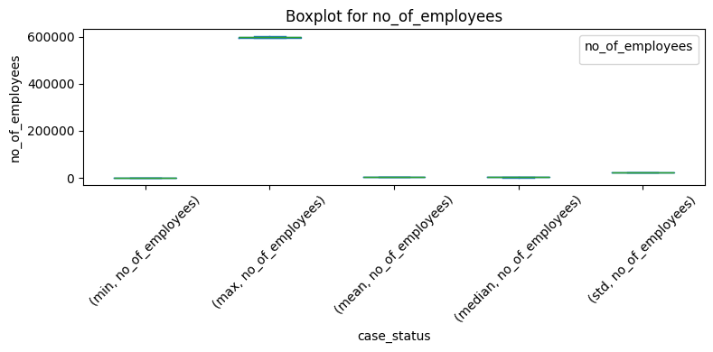

Pivot table for case_status for yr_of_estab

| case_status | min yr_of_estab | max yr_of_estab | mean yr_of_estab | median yr_of_estab | std yr_of_estab | count yr_of_estab |
| --- | --- | --- | --- | --- | --- | --- |
| Certified | 1800 | 2016 | 1979.666765 | 1997.0 | 42.278601 | 17018 |
| Denied | 1800 | 2016 | 1978.893406 | 1997.0 | 42.541819 | 8462 |

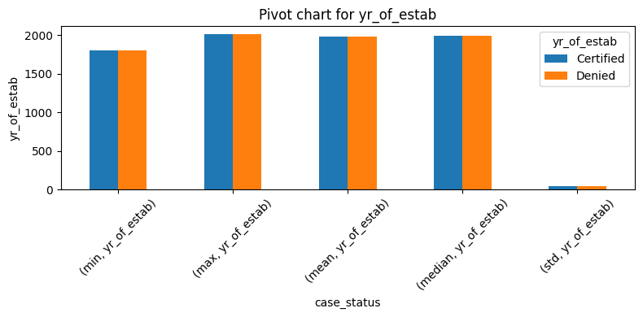

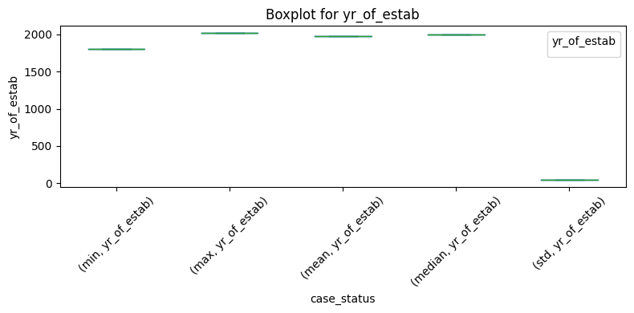

Pivot table for case_status for prevailing_wage

| case_status | min prevailing_wage | max prevailing_wage | mean prevailing_wage | median prevailing_wage | std prevailing_wage | count prevailing_wage |
| --- | --- | --- | --- | --- | --- | --- |
| Certified | 2.1367 | 318446.05 | 77293.619243 | 72486.27 | 52042.715576 | 17018 |
| Denied | 2.9561 | 319210.27 | 68748.681580 | 65431.46 | 53890.166031 | 8462 |

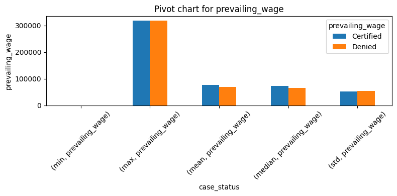

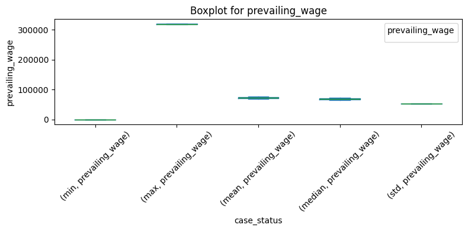

```python
pivot = EDA.pivot_table_all(data=df, target="case_status", chart_type="bar", figsize=(8, 4))
```

### Barplot Stacked

Stacked barplot for case_status for predictor: education_of_employee

```
case_status            Certified  Denied    All
education_of_employee
All                        17018    8462  25480
Bachelor's                  6367    3867  10234
High School                 1164    2256   3420
Master's                    7575    2059   9634
Doctorate                   1912     280   2192
----------------------------------------------------------------------------------------------------
```

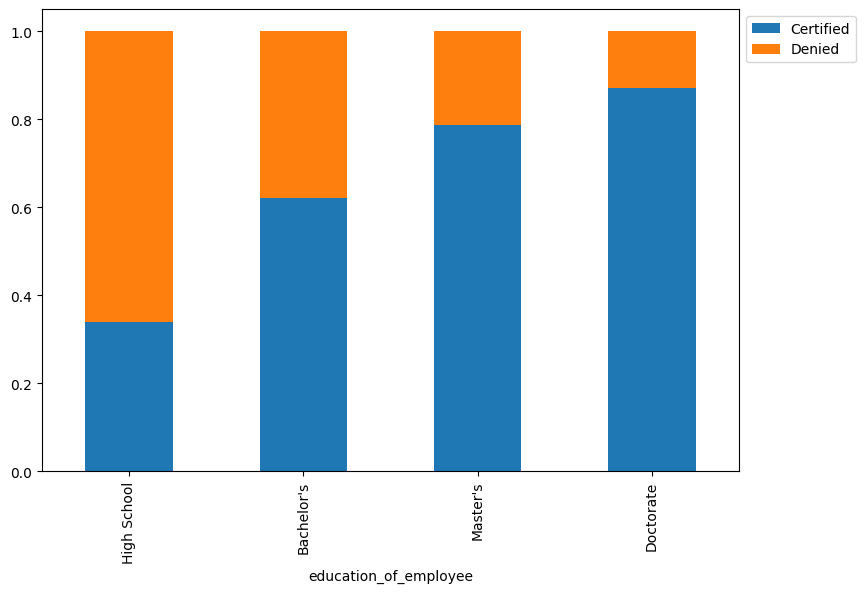

Stacked barplot for case_status for predictor: region_of_employment

```
case_status           Certified  Denied    All
region_of_employment
All                       17018    8462  25480
Northeast                  4526    2669   7195
West                       4100    2486   6586
South                      4913    2104   7017
Midwest                    3253    1054   4307
Island                      226     149    375
----------------------------------------------------------------------------------------------------
```

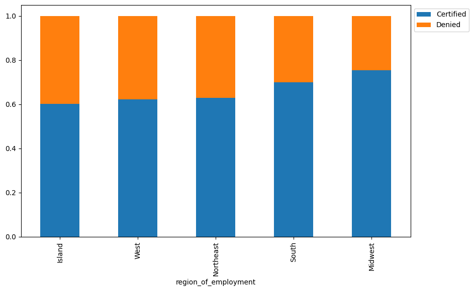

Stacked barplot for case_status for predictor: has_job_experience

```
case_status         Certified  Denied    All
has_job_experience
All                     17018    8462  25480
N                        5994    4684  10678
Y                       11024    3778  14802
----------------------------------------------------------------------------------------------------
```

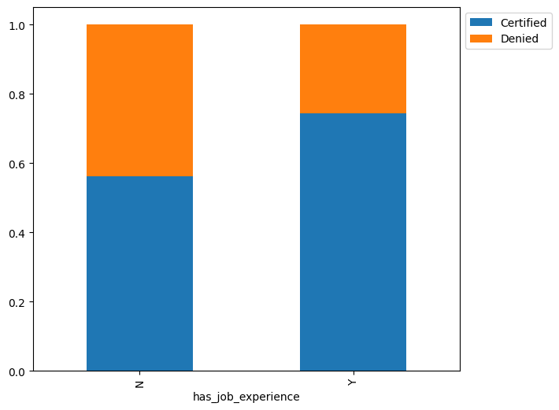

Stacked barplot for case_status for predictor: full_time_position

```
case_status         Certified  Denied    All
full_time_position
All                     17018    8462  25480
Y                       15163    7610  22773
N                        1855     852   2707
----------------------------------------------------------------------------------------------------
```

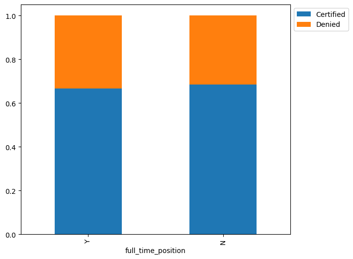

Stacked barplot for case_status for predictor: continent

```
case_status    Certified  Denied    All
continent
All                17018    8462  25480
Asia               11012    5849  16861
North America       2037    1255   3292
Europe              2957     775   3732
South America        493     359    852
Africa               397     154    551
Oceania              122      70    192
----------------------------------------------------------------------------------------------------
```

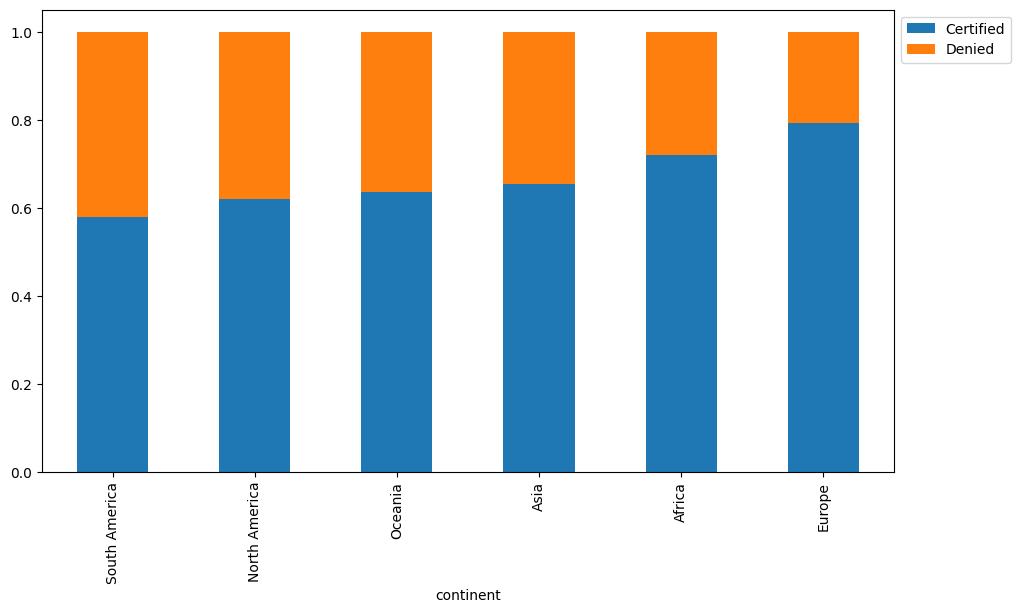

Stacked barplot for case_status for predictor: requires_job_training

```
case_status            Certified  Denied    All
requires_job_training
All                        17018    8462  25480
N                          15012    7513  22525
Y                           2006     949   2955
----------------------------------------------------------------------------------------------------
```

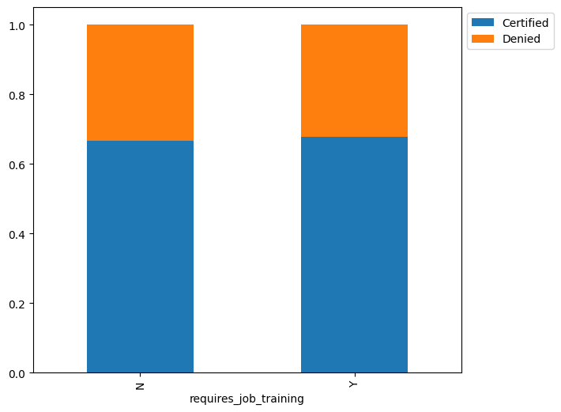

```python
EDA.barplot_stacked_all(data=df, target="case_status", predictors=
                        ["education_of_employee", "region_of_employment", "has_job_experience", "full_time_position", "continent", "requires_job_training"])

#  0   case_id                25480 non-null  object
#  1   continent              25480 non-null  object
#  2   education_of_employee  25480 non-null  object
#  3   has_job_experience     25480 non-null  object
#  4   requires_job_training  25480 non-null  object
#  5   no_of_employees        25480 non-null  int64
#  6   yr_of_estab            25480 non-null  int64
#  7   region_of_employment   25480 non-null  object
#  8   prevailing_wage        25480 non-null  float64
#  9   unit_of_wage           25480 non-null  object
#  10  full_time_position     25480 non-null  object
#  11  case_status            25480 non-null  object
```